# stat602_hw2

# 4.3

## First we read in the data set and remove the irrelavant columns.

```r
house <- read_excel("~/work/homework/AmesHousingData.xlsx")
house <- data.frame(Price = house$Price, Size = house$Size,
                    Fireplace = house$Fireplace,
                    Basementbath = house$`Bsmt Bath`, Land = house$Land, intersect = 1)
head(house)
```

|  | Price | Size | Fireplace | Basementbath | Land | intersect |
| --- | --- | --- | --- | --- | --- | --- |
| 1 | 141900 | 1762 | 0 | 1 | 7200 | 1 |
| 2 | 124000 | 2104 | 0 | 0 | 6300 | 1 |
| 3 | 109900 | 1040 | 0 | 0 | 6240 | 1 |
| 4 | 105000 | 1220 | 0 | 0 | 6120 | 1 |
| 5 | 84900 | 1177 | 0 | 0 | 7218 | 1 |
| 6 | 200000 | 2234 | 2 | 1 | 12975 | 1 |

## Now we need a matrix of all the possible regressor combinations.

```r
regMat <- expand.grid(c(TRUE,FALSE), c(TRUE,FALSE),
                      c(TRUE,FALSE), c(TRUE,FALSE))
regMat <- cbind(TRUE,regMat)

head(regMat)
```

|  | TRUE | Var1 | Var2 | Var3 | Var4 |
| --- | --- | --- | --- | --- | --- |
| 1 | TRUE | TRUE | TRUE | TRUE | TRUE |
| 2 | TRUE | FALSE | TRUE | TRUE | TRUE |
| 3 | TRUE | TRUE | FALSE | TRUE | TRUE |
| 4 | TRUE | FALSE | FALSE | TRUE | TRUE |
| 5 | TRUE | TRUE | TRUE | FALSE | TRUE |
| 6 | TRUE | FALSE | TRUE | FALSE | TRUE |

## Then we construct a formula so that from each row of regMat we can determine the the regressor combinations.

```r
formu <- function(vec)
{
  vec <- as.matrix(vec)
  regressors <- c("intersect","Size", "Fireplace", "Basementbath", "Land")
  out <- as.formula(paste(c("Price ~ 0", regressors[vec]), collapse=" + "))

  return(out)
}

formu(regMat[1,])
```

```
## Price ~ 0 + intersect + Size + Fireplace + Basementbath + Land
## <environment: 0xc565eb0>
```

## Cross-validation using **caret** package

```r
ctrl <- trainControl(method = "repeatedcv", repeats = 5, number = 8)

RMSE <- numeric(16)
for(i in 1:length(RMSE)){
  model_caret <- train(formu(regMat[i,]), data = house, trControl = ctrl, method = "lm")
  RMSE[i] = model_caret$results[,2]
}
RMSE
```

```
##  [1] 22148.59 26946.48 24321.32 33031.01 22328.77 27716.87 24960.70
##  [8] 33238.79 22564.36 27859.21 26731.63 36040.99 23435.52 28809.20
## [15] 27703.93 36567.04
```

```r
order(RMSE)
```

```
##  [1]  1  5  9 13  3  7 11  2 15  6 10 14  4  8 12 16
```

```r
regMat
```

| TRUE | Var1 | Var2 | Var3 | Var4 |
| --- | --- | --- | --- | --- |
| TRUE | TRUE | TRUE | TRUE | TRUE |
| TRUE | FALSE | TRUE | TRUE | TRUE |
| TRUE | TRUE | FALSE | TRUE | TRUE |
| TRUE | FALSE | FALSE | TRUE | TRUE |
| TRUE | TRUE | TRUE | FALSE | TRUE |
| TRUE | FALSE | TRUE | FALSE | TRUE |
| TRUE | TRUE | FALSE | FALSE | TRUE |
| TRUE | FALSE | FALSE | FALSE | TRUE |
| TRUE | TRUE | TRUE | TRUE | FALSE |
| TRUE | FALSE | TRUE | TRUE | FALSE |

[output cut: 6 more lines]

We can see that the full model has the smallest mean squared prediction error.

# 4.4

First read in the dataset:

```r
glass <- read.csv("~/work/homework/glass.data", header=FALSE)
names(glass) <- c("Id", "RI", "Na", "Mg", "Al", "Si", "K", "Ca", "Ba", "Fe", "Type")
glass_sub <- subset(glass, Type %in% c(1,2))
glass_sub$Type <- as.factor(glass_sub$Type)
```

## (a)

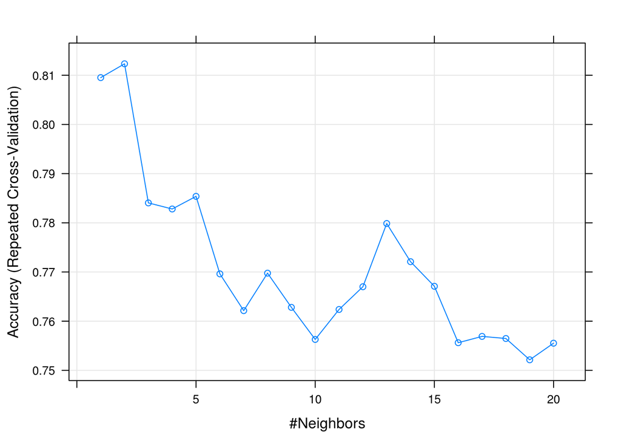

```r
ctrl <- trainControl(method="repeatedcv",repeats = 10, number = 10)
knnFit <- train(Type ~ . - Id, data = glass_sub, method = "knn", trControl = ctrl, preProcess = c("center","scale"), tuneGrid = expand.grid(k = 1:20) , tuneLength = 30)
plot(knnFit)
```

## (b)

See hand-written solution.

# 5.1

## (a)

```r
X <- c(2, 4, 3, 5, 1, 4, 3, 4, 2, 3, 7, 5, 6, 4, 4, 2, 5, 1, 2, 4)
X <- matrix(X, nrow = 5)

qrObj <- qr(X)
svdObj <- svd(X)
```

The Q matrix and R matrix are:

```r
qr.Q(qrObj)
```

```
##            [,1]        [,2]       [,3]        [,4]
## [1,] -0.2696799  0.57022480  0.7723433  0.04477265
## [2,] -0.5393599 -0.06579517 -0.1252449  0.56476381
## [3,] -0.4045199  0.37283929 -0.3548604 -0.70772210
## [4,] -0.6741999 -0.50442963  0.1043707 -0.12567762
## [5,] -0.1348400  0.52636136 -0.5009794  0.40295387
```

```r
qr.R(qrObj)
```

```
##           [,1]      [,2]       [,3]      [,4]
## [1,] -7.416198 -6.067799 -10.247838 -5.528439
## [2,]  0.000000  4.145096   5.987360  2.280899
## [3,]  0.000000  0.000000   1.064581 -1.231574
## [4,]  0.000000  0.000000   0.000000  3.566102
```

The colums of Q matrix give the bases for $C(\textbf{X})$.

The SVD results are:

```r
svdObj
```

```
## $d
## [1] 16.5812586  3.7842977  3.3820909  0.5499212
##
## $u
##            [,1]       [,2]       [,3]        [,4]
## [1,] -0.4993567  0.5283913  0.1647824 -0.66384835
## [2,] -0.5040186 -0.5891454  0.1259937 -0.11349453
## [3,] -0.4582533  0.4878118 -0.2526166  0.64627429
## [4,] -0.3913976 -0.3254921 -0.6846703 -0.08815998
## [5,] -0.3652670 -0.1726408  0.6514474  0.34782427
##
## $v
##            [,1]       [,2]        [,3]        [,4]
## [1,] -0.4047825 -0.4324356 -0.79720334  0.11669381
## [2,] -0.4354972  0.2981978  0.18084854  0.82988796
## [3,] -0.7111504  0.4458822  0.03987313 -0.54209258
## [4,] -0.3751780 -0.7247528  0.57460488 -0.06167786
```

The U has columns spanning $C(\textbf{X})$.

## (b)

The eigen decomposition of $X^{'}X$ is：

```r
(V <- svdObj$v)
```

```
##            [,1]       [,2]        [,3]        [,4]
## [1,] -0.4047825 -0.4324356 -0.79720334  0.11669381
## [2,] -0.4354972  0.2981978  0.18084854  0.82988796
## [3,] -0.7111504  0.4458822  0.03987313 -0.54209258
## [4,] -0.3751780 -0.7247528  0.57460488 -0.06167786
```

```r
(D_sq <- diag(svdObj$d) %*% diag(svdObj$d))
```

```
##          [,1]     [,2]     [,3]      [,4]
## [1,] 274.9381  0.00000  0.00000 0.0000000
## [2,]   0.0000 14.32091  0.00000 0.0000000
## [3,]   0.0000  0.00000 11.43854 0.0000000
## [4,]   0.0000  0.00000  0.00000 0.3024134
```

The eigen decomposition of $XX^{'}$ is:

```r
(U <- svdObj$u)
```

```
##            [,1]       [,2]       [,3]        [,4]
## [1,] -0.4993567  0.5283913  0.1647824 -0.66384835
## [2,] -0.5040186 -0.5891454  0.1259937 -0.11349453
## [3,] -0.4582533  0.4878118 -0.2526166  0.64627429
## [4,] -0.3913976 -0.3254921 -0.6846703 -0.08815998
## [5,] -0.3652670 -0.1726408  0.6514474  0.34782427
```

```r
(D_sq <- diag(svdObj$d) %*% diag(svdObj$d))
```

```
##          [,1]     [,2]     [,3]      [,4]
## [1,] 274.9381  0.00000  0.00000 0.0000000
## [2,]   0.0000 14.32091  0.00000 0.0000000
## [3,]   0.0000  0.00000 11.43854 0.0000000
## [4,]   0.0000  0.00000  0.00000 0.3024134
```

## (c)

rank = 1

```r
( rank1approx <- best_approx(X, 1) )
```

```
##          [,1]     [,2]     [,3]     [,4]
## [1,] 3.351583 3.605900 5.888298 3.106459
## [2,] 3.382873 3.639565 5.943271 3.135461
## [3,] 3.075706 3.309089 5.403616 2.850758
## [4,] 2.626983 2.826318 4.615269 2.434854
## [5,] 2.451600 2.637627 4.307144 2.272298
```

rank = 2

```r
( rank2approx <- best_approx(X, 2) )
```

```
##          [,1]     [,2]     [,3]     [,4]
## [1,] 2.486889 4.202174 6.779880 1.657251
## [2,] 4.346989 2.974732 4.949176 4.751299
## [3,] 2.277419 3.859570 6.226726 1.512847
## [4,] 3.159640 2.459010 4.066050 3.327575
## [5,] 2.734121 2.442807 4.015839 2.745797
```

## (d)

First center the matrix:

```r
X_center <- scale(X, center = TRUE, scale = FALSE)

X_center_scale <- scale(X, center = T, scale = T)
```

```r
( svdObj2 <- svd(X_center) )
```

```
## $d
## [1] 3.8322510 3.3823499 2.0106498 0.4804676
##
## $u
##            [,1]       [,2]        [,3]        [,4]
## [1,] -0.5712672  0.1656304  0.28534764 -0.60398428
## [2,]  0.5089398  0.1143288  0.69563542  0.20976309
## [3,] -0.4996900 -0.2490239 -0.08995577  0.69296822
## [4,]  0.3402207 -0.6851706 -0.32383532 -0.33154457
## [5,]  0.2217967  0.6542353 -0.56719197  0.03279753
##
## $v
##            [,1]        [,2]      [,3]         [,4]
## [1,]  0.3436766 -0.80716469 0.4461250  0.177042475
## [2,] -0.3682374  0.17791687 0.2582385  0.875248373
## [3,] -0.5751820  0.03345965 0.6822505 -0.450089261
## [4,]  0.6445566  0.56188184 0.5184782  0.003988055
```

```r
( svdObj3 <- svd(X_center_scale) )
```

```
## $d
## [1] 3.0431883 2.1387235 1.3876419 0.4892004
##
## $u
##            [,1]         [,2]       [,3]        [,4]
## [1,] -0.5985980 -0.003516761  0.1400083 -0.64966586
## [2,]  0.3012174  0.224786627  0.7869330  0.19868439
## [3,] -0.4397787 -0.343527972 -0.1595103  0.68054368
## [4,]  0.5757526 -0.580732932 -0.2401616 -0.27125742
## [5,]  0.1614067  0.702991038 -0.5272694  0.04169521
##
## $v
##            [,1]       [,2]      [,3]         [,4]
## [1,]  0.3592298 -0.6917233 0.5565679  0.287584734
## [2,] -0.6339580  0.1305970 0.1900625  0.738185562
## [3,] -0.5983454 -0.1695573 0.4907728 -0.610225552
## [4,]  0.3332176  0.6897200 0.6428456 -0.001368531
```

The principal component directions:

```r
svdObj2$v
```

```
##            [,1]        [,2]      [,3]         [,4]
## [1,]  0.3436766 -0.80716469 0.4461250  0.177042475
## [2,] -0.3682374  0.17791687 0.2582385  0.875248373
## [3,] -0.5751820  0.03345965 0.6822505 -0.450089261
## [4,]  0.6445566  0.56188184 0.5184782  0.003988055
```

```r
svdObj3$v
```

```
##            [,1]       [,2]      [,3]         [,4]
## [1,]  0.3592298 -0.6917233 0.5565679  0.287584734
## [2,] -0.6339580  0.1305970 0.1900625  0.738185562
## [3,] -0.5983454 -0.1695573 0.4907728 -0.610225552
## [4,]  0.3332176  0.6897200 0.6428456 -0.001368531
```

The “loadings” of the first principal component:

```r
svdObj2$v[,1]
```

```
## [1]  0.3436766 -0.3682374 -0.5751820  0.6445566
```

```r
svdObj3$v[,1]
```

```
## [1]  0.3592298 -0.6339580 -0.5983454  0.3332176
```

The principal components:

```r
X_center %*% svdObj2$v
```

```
##            [,1]       [,2]       [,3]        [,4]
## [1,] -2.1892395  0.5602201  0.5737342 -0.29019489
## [2,]  1.9503851  0.3867000  1.3986792  0.10078437
## [3,] -1.9149375 -0.8422861 -0.1808695  0.33294879
## [4,]  1.3038112 -2.3174867 -0.6511194 -0.15929643
## [5,]  0.8499806  2.2128526 -1.1404244  0.01575815
```

```r
X_center_scale %*% svdObj3$v
```

```
##            [,1]         [,2]       [,3]        [,4]
## [1,] -1.8216464 -0.007521379  0.1942814 -0.31781681
## [2,]  0.9166614  0.480756438  1.0919812  0.09719649
## [3,] -1.3383294 -0.734711340 -0.2213431  0.33292225
## [4,]  1.7521236 -1.242027160 -0.3332583 -0.13269924
## [5,]  0.4911909  1.503503442 -0.7316611  0.02039731
```

## (e)

The rank = 1 approximation:

```r
( rank1approx_center <- best_approx(X_center, 1) )
```

```
##            [,1]       [,2]       [,3]       [,4]
## [1,] -0.7523905  0.8061597  1.2592112 -1.4110888
## [2,]  0.6703018 -0.7182046 -1.1218265  1.2571337
## [3,] -0.6581193  0.7051515  1.1014376 -1.2342856
## [4,]  0.4480894 -0.4801120 -0.7499288  0.8403802
## [5,]  0.2921185 -0.3129946 -0.4888936  0.5478606
```

```r
( rank1approx_center_scale <- best_approx(X_center_scale, 1) )
```

```
##            [,1]       [,2]       [,3]       [,4]
## [1,] -0.6543898  1.1548473  1.0899737 -0.6070047
## [2,]  0.3292921 -0.5811248 -0.5484801  0.3054477
## [3,] -0.4807678  0.8484446  0.8007832 -0.4459550
## [4,]  0.6294151 -1.1107727 -1.0483750  0.5838385
## [5,]  0.1764504 -0.3113944 -0.2939018  0.1636735
```

The rank = 2 approximation:

```r
( rank1approx_center <- best_approx(X_center, 2) )
```

```
##             [,1]       [,2]       [,3]       [,4]
## [1,] -1.20458032  0.9058323  1.2779560 -1.0963113
## [2,]  0.35817116 -0.6494042 -1.1088876  1.4744134
## [3,]  0.02174434  0.5552946  1.0732550 -1.7075509
## [4,]  2.31868287 -0.8924320 -0.8274711 -0.4617735
## [5,] -1.49401805  0.0807092 -0.4148523  1.7912223
```

```r
( rank1approx_center_scale <- best_approx(X_center_scale, 2) )
```

```
##              [,1]       [,2]       [,3]       [,4]
## [1,] -0.649187041  1.1538651  1.0912490 -0.6121924
## [2,] -0.003258318 -0.5183395 -0.6299958  0.6370351
## [3,]  0.027449121  0.7524935  0.9253588 -0.9527000
## [4,]  1.488554221 -1.2729777 -0.8377803 -0.2728124
## [5,] -0.863557983 -0.1150414 -0.5488317  1.2006698
```

## (f)

```r
cov_matrix_center <- 1/5 * t(X_center) %*% X_center
cov_matrix_center_scale <- 1/5 * t(X_center_scale) %*% X_center_scale

( eigenX <- eigen( cov_matrix_center ) )
```

```
## eigen() decomposition
## $values
## [1] 2.93722954 2.28805812 0.80854251 0.04616983
##
## $vectors
##            [,1]        [,2]       [,3]         [,4]
## [1,]  0.3436766  0.80716469 -0.4461250  0.177042475
## [2,] -0.3682374 -0.17791687 -0.2582385  0.875248373
## [3,] -0.5751820 -0.03345965 -0.6822505 -0.450089261
## [4,]  0.6445566 -0.56188184 -0.5184782  0.003988055
```

```r
( best_approx(cov_matrix_center, 1) )
```

```
##            [,1]       [,2]       [,3]       [,4]
## [1,]  0.3469268 -0.3717198 -0.5806216  0.6506523
## [2,] -0.3717198  0.3982846  0.6221155 -0.6971509
## [3,] -0.5806216  0.6221155  0.9717365 -1.0889408
## [4,]  0.6506523 -0.6971509 -1.0889408  1.2202816
```

```r
( best_approx(cov_matrix_center, 2) )
```

```
##            [,1]       [,2]       [,3]       [,4]
## [1,]  1.8376307 -0.7003038 -0.6424162 -0.3870534
## [2,] -0.7003038  0.4707118  0.6357364 -0.4684178
## [3,] -0.6424162  0.6357364  0.9742981 -1.0459245
## [4,] -0.3870534 -0.4684178 -1.0459245  1.9426472
```

```r
( eigenX <- eigen( cov_matrix_center_scale ) )
```

```
## eigen() decomposition
## $values
## [1] 1.85219898 0.91482763 0.38510998 0.04786341
##
## $vectors
##            [,1]       [,2]       [,3]         [,4]
## [1,]  0.3592298 -0.6917233 -0.5565679  0.287584734
## [2,] -0.6339580  0.1305970 -0.1900625  0.738185562
## [3,] -0.5983454 -0.1695573 -0.4907728 -0.610225552
## [4,]  0.3332176  0.6897200 -0.6428456 -0.001368531
```

```r
( best_approx(cov_matrix_center_scale, 1) )
```

```
##            [,1]       [,2]       [,3]       [,4]
## [1,]  0.2390190 -0.4218135 -0.3981182  0.2217114
## [2,] -0.4218135  0.7444038  0.7025869 -0.3912696
## [3,] -0.3981182  0.7025869  0.6631191 -0.3692900
## [4,]  0.2217114 -0.3912696 -0.3692900  0.2056571
```

```r
( best_approx(cov_matrix_center_scale, 2) )
```

```
##            [,1]       [,2]       [,3]       [,4]
## [1,]  0.6767468 -0.5044563 -0.2908210 -0.2147486
## [2,] -0.5044563  0.7600067  0.6823293 -0.3088662
## [3,] -0.2908210  0.6823293  0.6894201 -0.4762764
## [4,] -0.2147486 -0.3088662 -0.4762764  0.6408530
```

# Problem 2

Making up a matrix:

```r
mother_wavelet <- function(x){

  value = ( x > 0 && x <= 1/2 ) - ( x > 1/2 && x <= 1)

  return(value)
}

haar_basis <- function(x){
  index <- 1;
  row <- numeric(16)
  for(m in 0:3)
    for( j in 0:( 2^m - 1 ) ){
      row[index] = sqrt(2^m) * mother_wavelet( (2^m) * ( x - j / (2^m) ) )
      index = index + 1
    }

  return(row)
}

x_trans <- ( data2$x - min(data2$x) )/( max(data2$x) - min(data2$x) )
X_h <- t( apply(as.matrix(x_trans), 1, haar_basis) )
```

## (a)

```r
( fit_ols <- lm(y~x, data = data2) )
```

```
##
## Call:
## lm(formula = y ~ x, data = data2)
##
## Coefficients:
## (Intercept)            x
##     -0.2948       0.1922
```

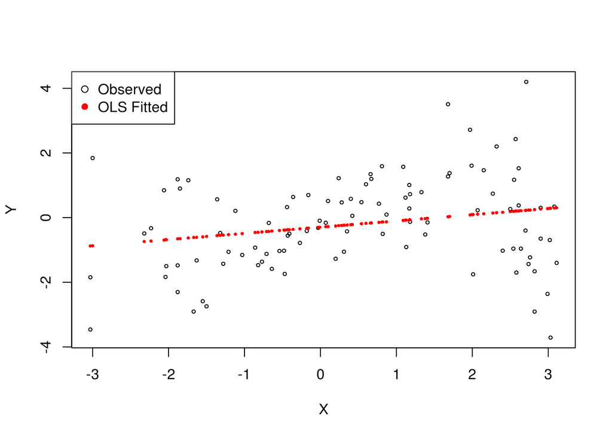

```r
plot(x = data2$x, y = data2$y, ylab = "Y", xlab = "X",
     pch = 1, cex = 0.5)
points(x = data2$x, y = fit_ols$fitted.values, pch = 16,
       col = "red", cex = 0.5)
legend("topleft", legend = c("Observed", "OLS Fitted"), col = c("black", "red"),
       pch = c(1, 16))
```

## (b)

```r
y_centered <- data2$y - mean( data2$y )

get_lambda <- function(M)
{
  fit_lasso <- glmnet(X_h, y_centered, standardize = T, pmax = M,nlambda = 20000)
  return( min(fit_lasso$lambda) )
}

get_predicted <- function(lambda)
{
  fit_lasso <- glmnet(X_h, y_centered, standardize = T, lambda = lambda)
  value = predict(fit_lasso, X_h)

  return(value)
}

get_coefficient_vector <- function(lambda){
  fit_lasso <- glmnet(X_h, y_centered, standardize = T, lambda = lambda)
  return(fit_lasso$beta)
}

M <- c(2,4,8)
lambda <- apply(as.matrix(M), 1, get_lambda)
value <- apply(as.matrix(lambda), 1, get_predicted) + mean(data2$y)

( coef <- apply( as.matrix(lambda), 1, get_coefficient_vector) )
```

```
## [[1]]
## 16 x 1 sparse Matrix of class "dgCMatrix"
##              s0
## V1  -0.03994013
## V2   .
## V3   .
## V4   .
## V5   .
## V6   .
## V7   .
## V8   .
## V9   .
## V10  .
## V11  .
## V12  .
## V13  .
## V14  .
## V15  0.02880334
## V16  .
##
## [[2]]
## 16 x 1 sparse Matrix of class "dgCMatrix"
##              s0
## V1  -0.30242980
## V2   .
## V3   .
## V4   0.09544829
## V5   .
## V6   .
## V7   0.25349740
## V8   .
## V9   .
## V10  .
## V11  .
## V12  .
## V13  .
## V14  .
## V15  0.20237856
## V16  .
##
## [[3]]
## 16 x 1 sparse Matrix of class "dgCMatrix"
##               s0
## V1  -0.391467689
## V2   .
## V3   .
## V4   0.175157628
## V5   .
## V6   .
## V7   0.347304902
## V8   0.205501442
## V9   .
## V10  0.031114449
## V11  .
## V12 -0.061899306
## V13  .
## V14  0.003836725
## V15  0.264369490
## V16  .
```

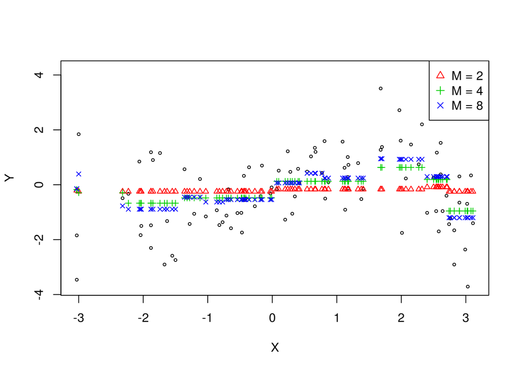

```r
plot(x = data2$x, y = data2$y, ylab = "Y", xlab = "X",
     pch = 1, cex = 0.5)

points(x = data2$x, y = value[,1], cex = 0.75, pch = 2, col = 2)
points(x = data2$x, y = value[,2], cex = 0.75, pch = 3, col = 3)
points(x = data2$x, y = value[,3], cex = 0.75, pch = 4, col = 4)

legend("topright", legend = c("M = 2", "M = 4", "M = 8"), col = c(2,3,4), pch = c(2,3,4))
```

# Problem 3

```r
knot <- c(0, .1, .3, .5, .7, .9, 1)
K <- length(knot)

only_positive <- function(x){
  value <- ifelse(x >= 0, x, 0)

  return(value)
}

make_row <- function(x){
  row <- numeric(K)
  row[1] = 1
  row[2] = x

  for(j in 1:(K - 2)){
    value = only_positive( ( x - knot[j] )^3 )
    -( knot[K] - knot[j] )/( knot[K] - knot[K-1] ) * only_positive( (x - knot[K -1])^3 )
    +( knot[K-1] - knot[j] )/( knot[K] - knot[K-1] ) * only_positive( (x - knot[K])^3 )

    row[j+2] = value
  }

  return(row)
}

x_trans <- ( data2$x - min(data2$x) )/( max(data2$x) - min(data2$x) )
X_h_3 <- t( apply(as.matrix(x_trans), 1, make_row) )
```

Then to find $\hat{\beta}^{OLS}$:

```r
fit_ols <- lm(data2$y ~ 0 + X_h_3)
fit_ols$coefficients
```

```
##      X_h_31      X_h_32      X_h_33      X_h_34      X_h_35      X_h_36
##   -1.190293    8.843849 -226.408590  434.236477 -343.350843  193.448300
##      X_h_37
## -228.230208
```

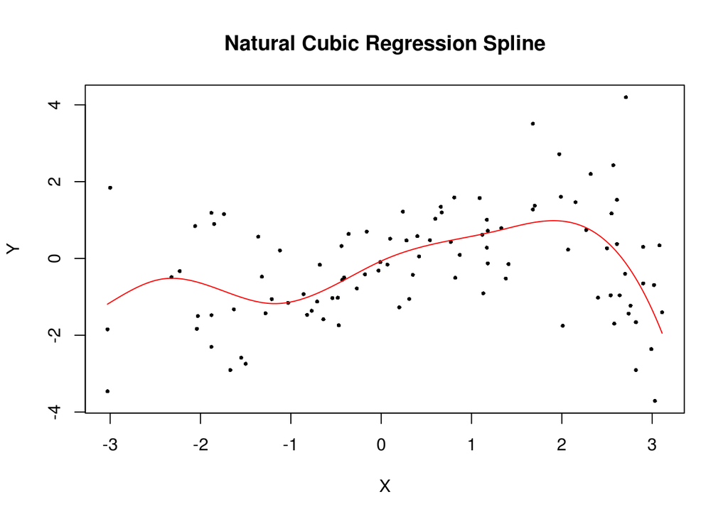

```r
x_plot <- seq(from = min( data2$x ), to = max( data2$x), length.out = 500)
x_plot_trans <- ( x_plot - min(data2$x) )/( max(data2$x) - min(data2$x) )
x_plot_h <- t( apply(as.matrix(x_plot_trans), 1, make_row) )
y_plot <- x_plot_h %*% fit_ols$coefficients

plot(x = data2$x, y = data2$y, pch = 16, cex = 0.5,
     ylab = "Y", xlab = "X", main = "Natural Cubic Regression Spline")
lines(x = x_plot, y = y_plot, col = "red")
```

# Problem 4

## (a)

```r
y <- c(0, 1.5, 2, 0.5, 0, -0.5,
       0, 1.5, 3.5, 4.5, 3.5)

Omiga <- matrix(0, nrow = N, ncol = N)

for( j in 1:(N-2) )
  for( k in j:(N-2)){
    if(k == j){
      Omiga[j+2, k+2] = 12 * (x[N-1] - x[j])^2 * (x[N] - x[j])
    } else {
      Omiga[j+2, k+2] = 6 * ( x[N-1] - x[k] )^2 * ( 2*x[N-1] + x[k] - 3*x[j] ) +
        12 * ( x[N-1] - x[k] ) * ( x[N-1] - x[j] ) * ( x[N] - x[N-1] )
      Omiga[k+2, j+2] = Omiga[j+2, k+2]
    }
  }
```

```r
H_matrix <- matrix(nrow = N, ncol = N)
for(i in 1:N)
  for(j in 1:N){
    H_matrix[i, j] <- compute_H(i, j)
  }
H_matrix
```

```
##       [,1] [,2]  [,3]  [,4]  [,5]  [,6]  [,7]  [,8]  [,9] [,10] [,11]
##  [1,]    1  0.0 0.000 0.000 0.000 0.000 0.000 0.000 0.000 0.000 0.000
##  [2,]    1  0.1 0.001 0.000 0.000 0.000 0.000 0.000 0.000 0.000 0.000
##  [3,]    1  0.2 0.008 0.001 0.000 0.000 0.000 0.000 0.000 0.000 0.000
##  [4,]    1  0.3 0.027 0.008 0.001 0.000 0.000 0.000 0.000 0.000 0.000
##  [5,]    1  0.4 0.064 0.027 0.008 0.001 0.000 0.000 0.000 0.000 0.000
##  [6,]    1  0.5 0.125 0.064 0.027 0.008 0.001 0.000 0.000 0.000 0.000
##  [7,]    1  0.6 0.216 0.125 0.064 0.027 0.008 0.001 0.000 0.000 0.000
##  [8,]    1  0.7 0.343 0.216 0.125 0.064 0.027 0.008 0.001 0.000 0.000
##  [9,]    1  0.8 0.512 0.343 0.216 0.125 0.064 0.027 0.008 0.001 0.000
## [10,]    1  0.9 0.729 0.512 0.343 0.216 0.125 0.064 0.027 0.008 0.001
## [11,]    1  1.0 0.990 0.720 0.504 0.336 0.210 0.120 0.060 0.024 0.006
```

```r
K_matrix <- solve( t(H_matrix) ) %*% Omiga %*% solve( H_matrix )
K_matrix <- ( K_matrix + t(K_matrix) )/2
```

## (b)

```r
K_eigen <- eigen(K_matrix); K_eigen$values
```

```
##  [1]  4.366292e+04  3.333961e+04  2.200669e+04  1.282846e+04  6.610687e+03
##  [6]  2.938555e+03  1.060305e+03  2.713642e+02  3.508288e+01 -1.958878e-12
## [11] -3.244671e-12
```

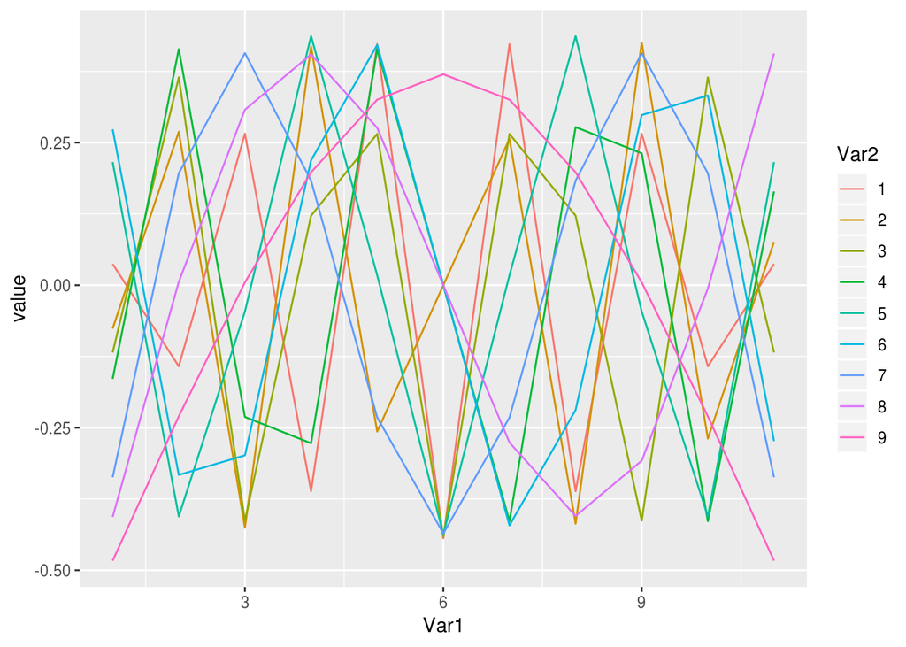

```r
reshape2::melt(K_eigen$vectors) %>% mutate(Var2 = as.factor(Var2)) %>%
  filter(Var2 %in% 1:9) %>% ggplot() + geom_line(aes(x = Var1, y = value, col = Var2))
```

A large eigen value of $K$ corresponds to a small eigen value of $S_{\lambda}$. From the plot below, we can draw the conclusion that the `Y[c(2,3,6,9)]` will get suppressed most in the smoothing.

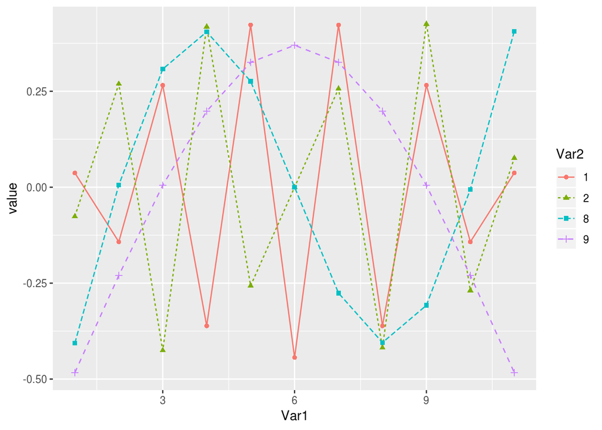

```r
reshape2::melt(K_eigen$vectors) %>%
  mutate(Var2 = as.factor(Var2)) %>%
  filter( Var2 %in% c(1:2, 8:9) ) %>%
  ggplot(aes( x = Var1, y = value, col = Var2)) + geom_line(aes( linetype = Var2 )) +geom_point(aes(pch = Var2))
```

## (c)

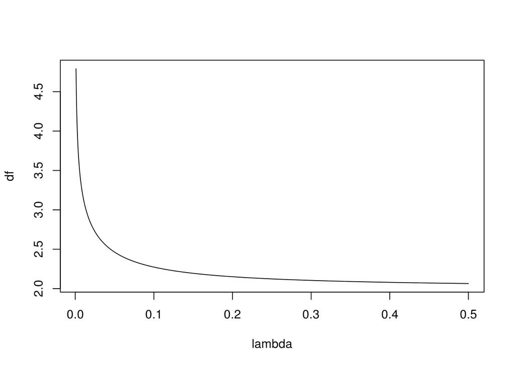

```r
compute_df <- function(lambda, eta_array, target = 0){
  eta_array[10:11] = 0
  value <- sum( 1/(1 + lambda * eta_array) )

  return( value-target )
}

lambda <- as.matrix( seq(from = 0.001, to = 0.5, by = 0.0001) )
df <- apply(lambda, 1, compute_df, eta_array = K_eigen$values)

plot(x = lambda, y = df, type = "l")
```

```r
df <- c(2.5, 3, 4, 5)
lambda_roots_4 <- numeric(length(df))

for(i in 1:length(df)){
  lambda_roots_4[i] <- uniroot(function(x) compute_df(x, eta_array = K_eigen$values, target = df[i]), interval = c(0.0001, 2))$root
}
lambda_roots_4
```

```
## [1] 0.0448424394 0.0137079634 0.0026479555 0.0008216407
```

# Problem 5

## (a)

```r
x <- seq(0,1,by=0.1)
N <- length(x)
B <- as.matrix( cbind(1,x) )

compute_K_lambda <- function(lambda, x0, xi){
  value <- dnorm( (x0 - xi)/lambda )

  return(value)
}

compute_W <- function(x0, lambda){
  value <- numeric(N)
  for(i in 1:N){
    value[i] <- compute_K_lambda(lambda, x0, x[i])
  }

  return(diag(value))
}

compute_I <- function(lambda, x0){
  W <- compute_W(x0, lambda)

  part1 <- matrix(c(1,x0), nrow = 1)
  part2 <- solve( t(B) %*% W %*% B)
  part3 <- t(B) %*% W

  value <- part1 %*% part2 %*% part3

  return(value)
}

get_trace_L <- function(lambda, target = 0){
  L <- apply(as.matrix( x ), 1, compute_I, lambda = lambda)

  return( tr(L) - target )
}
```

This is the plot of effective degree of freedom v.s. $log(\lambda)$:

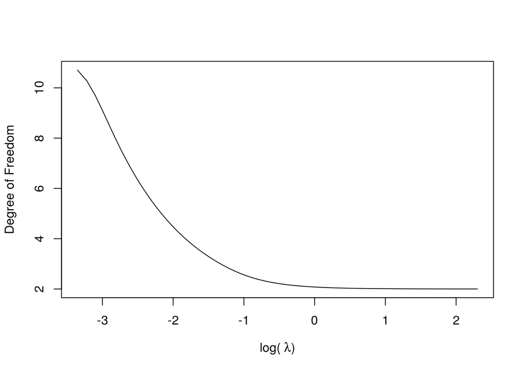

```r
lambda <- seq(0.035,10,length.out = 2000)
trace_I <- apply(as.matrix( lambda ), 1,get_trace_L)
plot(log(lambda), trace_I, ty = "l", ylab = "Degree of Freedom",
     xlab = expression( paste( "log(",~lambda,")" ) )
     )
```

Find out the value of alpha by solving the root:

```r
df <- c(2.5, 3, 4, 5)
lambda_roots <- numeric(length(df))

for(i in 1:length(df)){
  lambda_roots[i] <- uniroot(function(x) get_trace_L(x, target = df[i]), interval = c(0.05,4))$root
}

lambda_roots
```

```
## [1] 0.3915776 0.2642124 0.1609244 0.1146486
```

## (b)

```r
lambda5 <- lambda_roots[3]
lambda4 <- lambda_roots_4[3]

L_lambda5 <- t( apply(as.matrix( x ), 1, compute_I, lambda = lambda5) )
S_lambda4 <- solve( diag(1, nrow = 11) + lambda4*K_matrix )
```

The matrix difference is:

```r
L_lambda5 - S_lambda4
```

```
##               [,1]         [,2]         [,3]         [,4]         [,5]
##  [1,]  0.090027536 -0.011577964 -0.094409573 -0.053444610  0.009269582
##  [2,]  0.028821277  0.023347628 -0.019283615 -0.042654653 -0.026454779
##  [3,]  0.038764026  0.015740216 -0.020661092 -0.028294980 -0.027429832
##  [4,]  0.052673668  0.007797074 -0.015630840 -0.036983145 -0.025077386
##  [5,]  0.052563434  0.007659622 -0.011710767 -0.021773047 -0.035424474
##  [6,]  0.040489059  0.013278246 -0.005564228 -0.012537779 -0.019086010
##  [7,]  0.024457299  0.016186744  0.005322851 -0.006004389 -0.011640453
##  [8,]  0.011086811  0.013664341  0.012591005  0.004407607 -0.008059208
##  [9,]  0.002671861  0.008414849  0.012715407  0.011936735  0.001739538
## [10,] -0.001816245  0.003047093  0.008382383  0.013235838  0.013155994
## [11,] -0.004492881 -0.001816568  0.002662322  0.010931083  0.022859007
##                [,6]         [,7]         [,8]         [,9]        [,10]
##  [1,]  0.0299920680  0.022859007  0.010931083  0.002662322 -0.001816568
##  [2,]  0.0002190787  0.013155994  0.013235838  0.008382383  0.003047093
```

[output cut: 21 more lines]

The plots are:

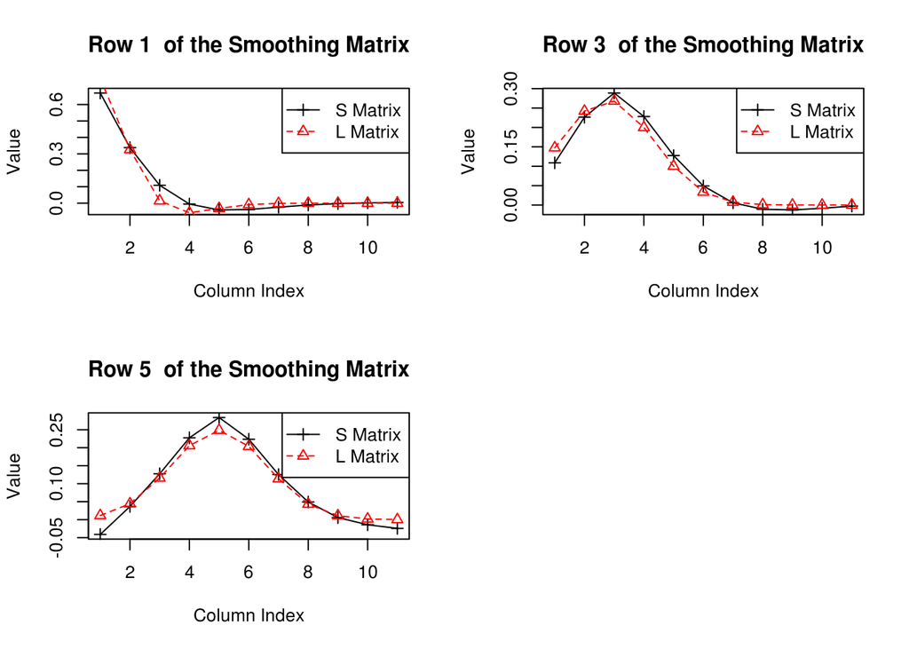

```r
par(mfrow = c(2,2))

for(i in c(1,3,5)){
  plot(x = 1:11, y = S_lambda4[i, ], xlab = "Column Index", col = 1,
     main = paste("Row", i, " of the Smoothing Matrix"), pch = 3, ylab = "Value")
  lines(x = 1:11, y = S_lambda4[i, ], col = 1, lty = 1)

  points(x = 1:11, y = L_lambda5[i, ], pch = 2, col = 2)
  lines(x = 1:11, y = L_lambda5[i, ], col = 2, lty = 2)

  legend("topright", legend = c("S Matrix", "L Matrix"), pch = c(3, 2), col = c(1, 2), lty = c(1, 2))
}
```

From the plots above, the two smoothing matrices are close to each other when the effective degree of freedom is the same.

# 6

## (a)

The largest effective degrees of freedom I can get for the locally weighted linear regression smoother with tricube kernel is about 4.72. If I try to go over it, the effective degrees of freedom will jump to 11, which means the fitted values are the same as the observed values.

```r
lambda_df5 <- uniroot(function(lambda) smooth.spline(x, y, lambda = lambda)$df-5,
                      interval = c(0.0001, 1) )$root
lambda_df9 <- uniroot(function(lambda) smooth.spline(x, y, lambda = lambda)$df-9,
                      interval = c(0.000001, 1))$root
cubic_smoothing_5 <- smooth.spline(x, y, lambda = lambda_df5)
cubic_smoothing_9 <- smooth.spline(x, y, lambda = lambda_df9)

tricube_5 <- loess(y~x, degree = 1, enp.target = 5)
( tricube_9 <- loess(y~x, degree = 1, enp.target = 9) )
```

```
## Call:
## loess(formula = y ~ x, enp.target = 9, degree = 1)
##
## Number of Observations: 11
## Equivalent Number of Parameters: 11
## Residual Standard Error: NaN
```

This is the plot for approximately 5 effective degrees of freedom:

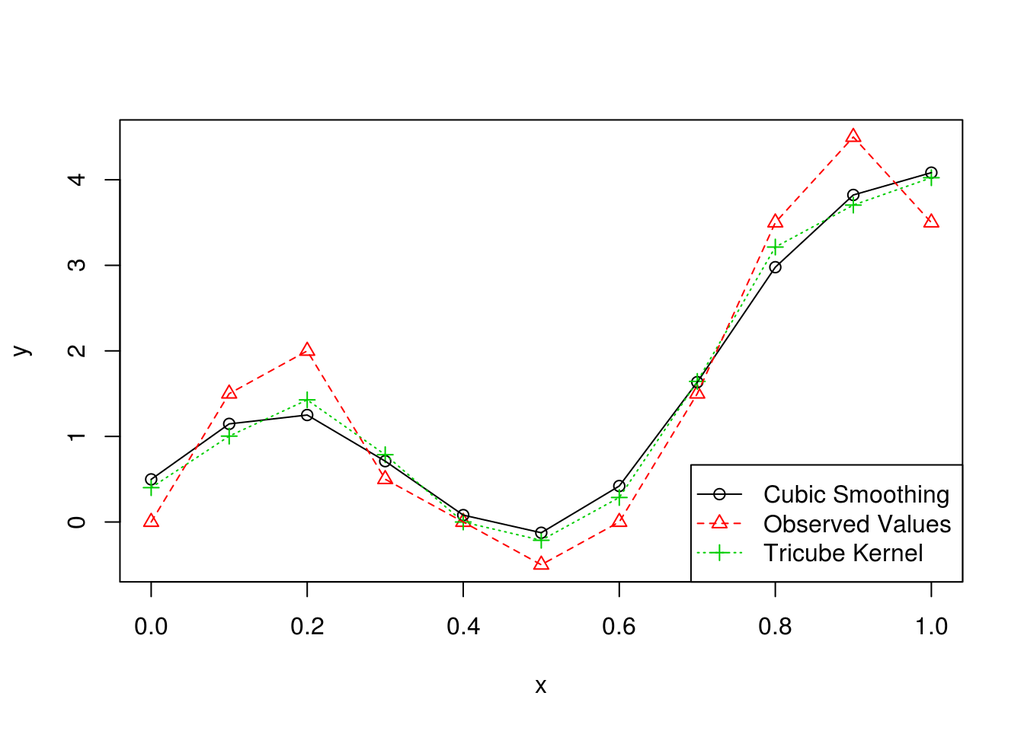

```r
plot(x, y, pch = 2, col = 2)
points(x, cubic_smoothing_5$y, ylab = "Y", xlab = "x")
points(x, tricube_5$fitted, pch = 3, col = 3)

lines(x, cubic_smoothing_5$y)
lines(x, tricube_5$fitted, lty = 3, col = 3)
lines(x, y, lty = 2, col = 2)
legend("bottomright", legend = c("Cubic Smoothing", "Observed Values", "Tricube Kernel"),
       pch = c(1, 2, 3), col = c(1, 2, 3), lty = c(1, 2, 3))
```

This is the plot for approximately 9 effective degrees of freedom:

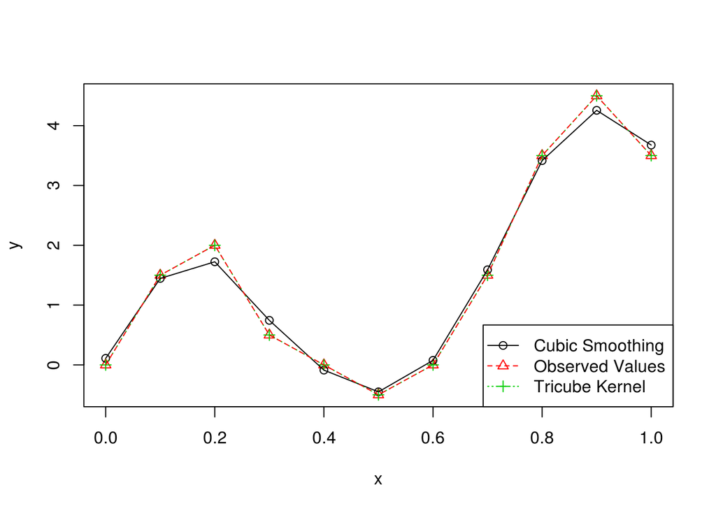

We can see that, the fitted value from locally weighted linear regression is the same as the observed one. The reason for that is explained above. Maybe it is caused by some numerical issues.

# Problem 7

```r
wineknn<- train(y=wine$quality,
                x=wine[,-12],
                method="knn",
                preProcess=c("center","scale"),
                trControl=trainControl(method="repeatedcv",repeats=100,number=10))

winenet<- train(y=wine$quality,
                x=wine[,-12],
                method="glmnet",
                preProcess=c("center","scale"),
                trControl=trainControl(method="repeatedcv",repeats=100,number=10))

winepcr<- train(y=wine$quality,
                x=wine[,-12],
                method="pcr",
                preProcess=c("center","scale"),
                trControl=trainControl(method="repeatedcv",repeats=100,number=10))

winepls<- train(y=wine$quality,
                x=wine[,-12],
                method="pls",
                preProcess=c("center","scale"),
                trControl=trainControl(method="repeatedcv",repeats=100,number=10))

winemars<- train(y=wine$quality,
                 x=wine[,-12],
                 method="earth",
                 preProcess=c("center","scale"),
                 trControl=trainControl(method="repeatedcv",repeats=100,number=10))

wineols<- lm(quality~.,data=wine)
```

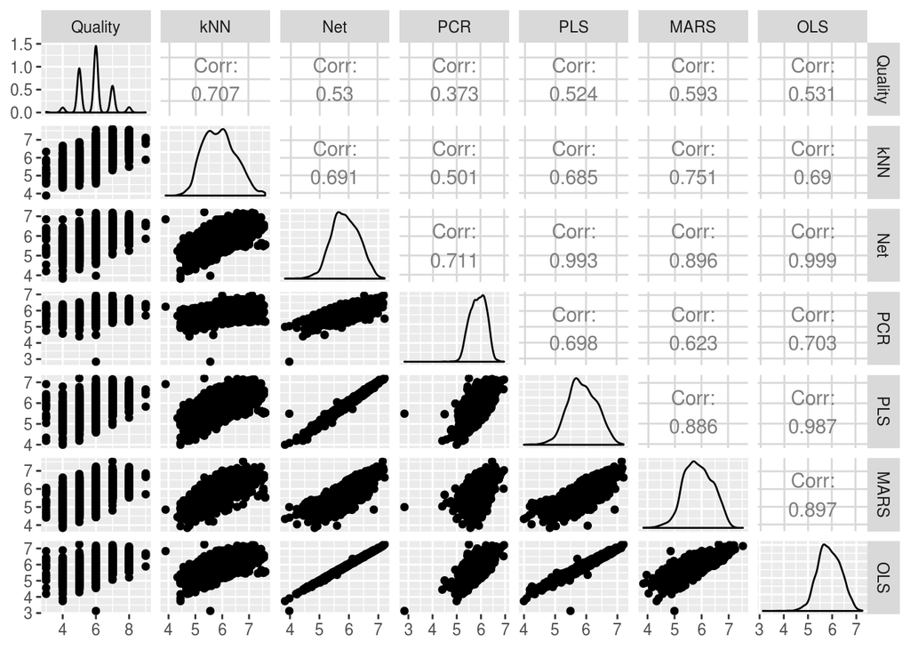

```r
winepred<- sapply(list(wineknn,winenet,winepcr,winepls,winemars,wineols),predict)
colnames(winepred)<- c("kNN","Net","PCR","PLS","MARS","OLS")

res<- data.frame(cbind(Quality=wine$quality,winepred))

ggpairs(res)
```

```r
round(cor(res),digits=2)
```

```
##         Quality  kNN  Net  PCR  PLS MARS  OLS
## Quality    1.00 0.71 0.53 0.37 0.52 0.59 0.53
## kNN        0.71 1.00 0.69 0.50 0.69 0.75 0.69
## Net        0.53 0.69 1.00 0.71 0.99 0.90 1.00
## PCR        0.37 0.50 0.71 1.00 0.70 0.62 0.70
## PLS        0.52 0.69 0.99 0.70 1.00 0.89 0.99
## MARS       0.59 0.75 0.90 0.62 0.89 1.00 0.90
## OLS        0.53 0.69 1.00 0.70 0.99 0.90 1.00
```

# Problem 8

## (a)

```r
x <- seq(0, 1, by = 0.1)
y <- c(0, 1.5, 2, 0.5, 0, -0.5, 0, 1.5, 3.5, 4.5, 3.5)

x_std <- scale(x, center = T, scale = T)
y_ctr <- scale(y, center = T, scale = FALSE)

K <- as.matrix( -1/2 * dist(x_std)^2 ) %>% exp

G <- matrix(nrow = 11, ncol = 11)
for(i in 1:11)
  for(j in 1:11){
    G[i, j] = K[i, j] - colMeans(K)[i] - rowMeans(K)[j] + mean(K)
  }
G
```

```
##              [,1]        [,2]        [,3]        [,4]        [,5]
##  [1,]  0.72982684  0.59948554  0.40416853  0.17923959 -0.03591672
##  [2,]  0.59948554  0.55801817  0.44007432  0.26283433  0.05920771
##  [3,]  0.40416853  0.44007432  0.41100439  0.31113756  0.15519990
##  [4,]  0.17923959  0.26283433  0.31113756  0.30014465  0.22158014
##  [5,] -0.03591672  0.05920771  0.15519990  0.22158014  0.23188956
##  [6,] -0.20963926 -0.13330264 -0.02578076  0.08828844  0.17597102
##  [7,] -0.32445509 -0.28406202 -0.19532794 -0.06972905  0.06564248
##  [8,] -0.37719216 -0.37623188 -0.32344136 -0.21663027 -0.06972905
##  [9,] -0.37505911 -0.40766663 -0.39430890 -0.32344136 -0.19532794
## [10,] -0.33090034 -0.38745656 -0.40766663 -0.37623188 -0.28406202
## [11,] -0.25955782 -0.33090034 -0.37505911 -0.37719216 -0.32445509
##              [,6]        [,7]        [,8]        [,9]       [,10]
##  [1,] -0.20963926 -0.32445509 -0.37719216 -0.37505911 -0.33090034
##  [2,] -0.13330264 -0.28406202 -0.37623188 -0.40766663 -0.38745656
```

[output cut: 21 more lines]

## (c)

```r
G_eigen <- eigen(G)

compute_T <- function(z, x){
  return( exp(-1/2 * ( x - z )^2 ) )
}

compute_S <- function(z, i){
  T_xi <- compute_T( z, x_std[i] )

  M <- 0
  for(j in 1:11){
    M <- M + compute_T( z, x_std[j] )
  }
  M <- M/11

  return(T_xi + M)
}
```

The function is becoming closer to 0 with decreasing eigenvalues, but the smallest eigen value is an outlier.

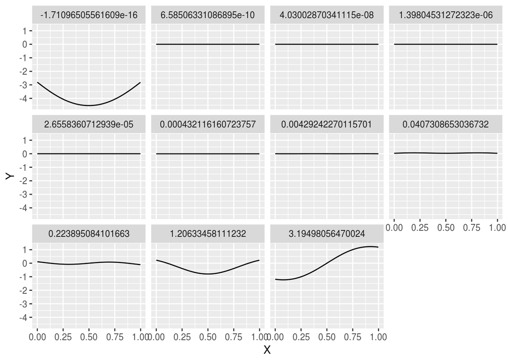

## (d)

The eigen decomposition is equivalent to SVD in this problem. The following is the plot:

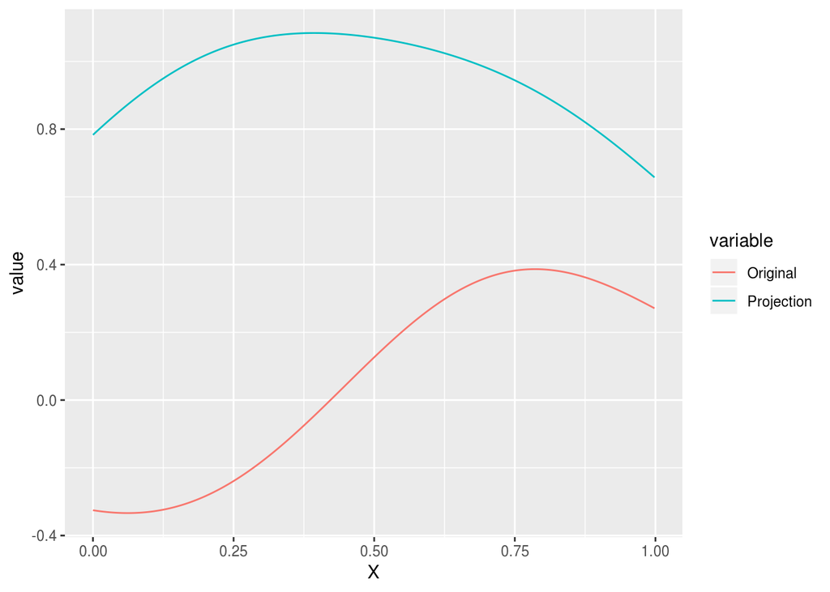